# Tutorial on ALAAM - NCRM

[Johan Koskinen](https://https://www.su.se/english/profiles/kosk-1.615440)

2024-10-31

# Introduction

This tutorial introduces aspects of the Bayesian estimation for auto-logistic actor attribute models (ALAAMs)(Robins, Pattison, and Elliott (2001), Daraganova (2009), and Daraganova and Robins (2013)) developed in Koskinen and Daraganova (2022).

## Preamble for ALAAM

The main functions are defined in `balaam’ which can be “loaded” from GitHub.

## Load program

```r
source("https://raw.githubusercontent.com/johankoskinen/ALAAM/main/balaam.R")
```

## Manual

A (proto-) manual is avaialble on GitHub [alaam_effects](https://github.com/johankoskinen/ALAAM/blob/main/alaam_effects.pdf).

## Dependencies

There are a number of dependencies in the functions but RStudio should prompt you to install of the following if you have not.

```r
require(MASS)
require('mvtnorm')
require('coda')
```

## Network packages

In particular, we will use sna (Butts 2016) and network (Butts 2015)

```r
require(sna)
require(network)
```

## Load data

We are looking at the s50 dataset, which is further described here: https://www.stats.ox.ac.uk/~snijders/siena/s50_data.htm

This dataset is available in ziped format online.

```r
temp <- tempfile()
download.file("https://www.stats.ox.ac.uk/~snijders/siena/s50_data.zip",temp)
adj <- as.matrix( read.table(unz(temp, "s50-network1.dat")) )
sport <- read.table(unz(temp, "s50-sport.dat"))
smoke <- read.table(unz(temp, "s50-smoke.dat"))
alcohol <- read.table(unz(temp, "s50-alcohol.dat"))
unlink(temp)
```

## Format data

```r
n <- nrow(adj)
adj <- as.matrix(adj) # convert from data.frame to matrix
smoke <- smoke[,2] # use wave 2
smoke[smoke<2] <- 0 # set non-smoker to 0
smoke[smoke>0] <- 1 # set occasional and regular to 1
sport <- sport-1
```

### Format for estimate.alaam()

The main estimation function `estimate.alaam` requires data to be in `data.frame` format (check `alaam_effects.pdf`)

```r
my.data <- data.frame(smoke=smoke, alcohol=alcohol[,1],sport=sport[,1])
```

Check data

```r
head(my.data)
```

```
##   smoke alcohol sport
## 1     0       3     1
## 2     1       2     0
## 3     0       2     0
## 4     0       2     1
## 5     0       3     1
## 6     0       4     1
```

### Descriptives

We might want to check what the association are like, for example with alcohol

```r
table(my.data$smoke,my.data$alcohol)
```

```
##
##      1  2  3  4  5
##   0  4 13 10  5  1
##   1  1  3  2  9  2
```

and with outdegree

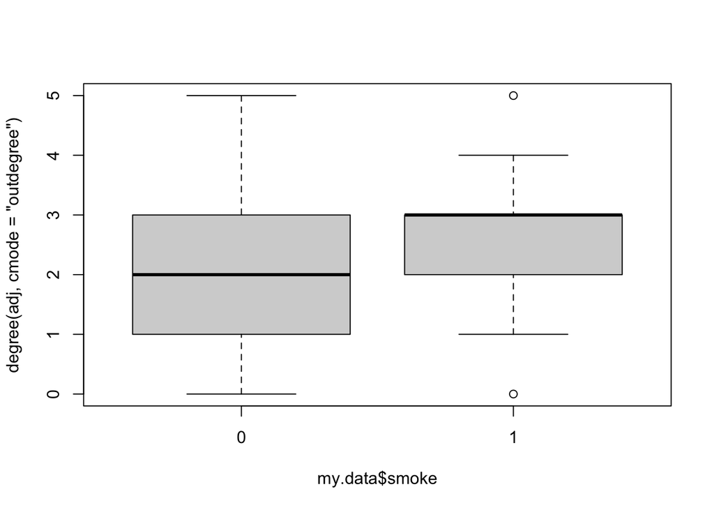

```r
boxplot(degree( adj , cmode = "outdegree") ~ my.data$smoke)
```

# Autologistic actor-attribute model

The social influence model developed by Robins, Pattison, and Elliott (2001) and later elaborated by Daraganova (2009) and Daraganova and Robins (2013) and now refered to as the autologistic actor-attribute model (ALAAM), is a model for binary nodal attributes $\boldsymbol{y}= \{Y_i:1 \leq i \leq n \}$, conditional on a network adjacency matrix $\mathbf{X} = \{ X_{ij}: (i,j)\in V \times V \}$.
$$p_{\boldsymbol{\theta}}(\boldsymbol{y} | \mathbf{X} ) = \exp \left\{
\boldsymbol{\theta}^{\top} \boldsymbol{z}(\boldsymbol{y},\mathbf{X}) -
\psi(\boldsymbol{\theta}; \mathbf{X}) \right\}$$
Here $\boldsymbol{z}(\boldsymbol{y},\mathbf{X})$ is a $p\times 1$ vector of statistics calculated for the the dependent variable $y$ and the network $x$.

This part of the tutorial takes you through the Bayesian inference scheme of Koskinen and Daraganova (2022).

## Specifying a model

Like for the function `lm`, and `glm`, the intuition of the formula is that the LHS is some transformation of the RHS. For ALAAM, we can think of the model specification in terms of the conditional logits

$${\rm{logit}}\left[ \Pr(Y_i = 1 \mid
\boldsymbol{y}_{-i},\boldsymbol{\theta})
\right]=\boldsymbol{\theta}^{\top}\boldsymbol{\omega}_i(\boldsymbol{y},\mathbf{X})=\theta_1\omega_{1i}(\boldsymbol{y},\mathbf{X})+\cdots
+\theta_p\omega_{pi}(\boldsymbol{y},\mathbf{X})$$
for the change statistics

$$\omega_{ji}(\boldsymbol{y},\mathbf{X})=z_j(\Delta_i^+\boldsymbol{y},\mathbf{X})-z_j(\Delta_i^-\boldsymbol{y},\mathbf{X})$$
are the differences in statistics evaluated on $\boldsymbol{y}$ when the variable $Y_i$ is forced to be $y_i=1$, for $\Delta_i^+\boldsymbol{y}$, and forced to be $y_i=0$, for $\Delta_i^-\boldsymbol{y}$.

In other words we can think of

```r
y ~ z1+z2+...+zp
```

```
## y ~ z1 + z2 + ... + zp
```

as stating that the LHS (`y`) should be the conditional logit, and the RHS be the “linear predictor”.

## Types of effects

As further described in `alaam.terms` (`alaam_effects.pdf`), there are *four* classes of effects:

1. Covariate effects
2. Network metrics
3. Contagion effects
4. Interactions of monadic covariates and congation effects

### Covariate effects

The effect of a covariate `x` on a dichotomous outcome variable `y` is specified as a standard formula

```r
y ~ x
```

```
## y ~ x
```

Any additional effect of an additional mondatic covariate `z` is added `+z`, e.g.

```r
y ~ x + z
```

```
## y ~ x + z
```

To include an interaction of two monadic covariates, the interaction symbol `*` is used

```r
y ~ x + z + x*z
```

```
## y ~ x + z + x * z
```

> The following standard formulae functions are not supported:

```r
y ~ x + I(x^2)# create the squared term manually and add it to data frame instead
```

```
## y ~ x + I(x^2)
```

```r
y ~ x + I(x>0)# create the indicator term manually and add it to data frame instead
```

```
## y ~ x + I(x > 0)
```

```r
y ~ -1 +x # the intercept term cannot be removed
```

```
## y ~ -1 + x
```

### Network effects

It is natural to include network metrics in your model. You are free to precalculate any network measures that you find useful and add them as monadic covariates. For example, you may want to add the effect of betweeness centrality or closeness centrality, `clc <- closeness(adj)` to your model, in which case you add `clc` to the data frame.

Some of network statistics that can be dervived from the **network activity** dependency assumption (Section 3.1.1 Network activity dependence, and also **Indirect Structural Influence**, Koskinen and Daraganova (2022)) are available as built in effects. For example, for a directed network, you can specify the effect of sending ties on the outcome `y` as

```r
y ~ odegree
```

```
## y ~ odegree
```

The effects that are available from formula are:

[output not shown]

### Contagion effects

Contagion effects are parameters of statistics that capture dependence among outcomes. These can be interpreted in terms of conditional distributions, for example for “simple” or “direct contagtion”
$${\rm{logit}}\left[\Pr(Y_i = 1 \mid
\boldsymbol{y}_{-i},\boldsymbol{\theta})\right]=\theta_{DC}\sum_{j\neq
i}y_jx_{ij}+c.$$

At the moment, the contagion effects that are implemented are:

[output not shown]

# Estimation examples

We will now illustrate two minimal examples of estimating models.

## Markov models

For a Markov model (Robins, Pattison, and Elliott 2001), the sufficient statistics are, degrees $x_{i\cdot}=\sum_j x_{ij}$, two-stars $\binom{x_{i\cdot}}{2}$, three-stars $\binom{x_{i\cdot}}{3}$, and triangles $\sum_{j,k \neq i}x_{ij}x_{ik}x_{jk}$. These could be be pre-calculated and used as monadic covariates but we will draw on the functionality of `balaam`.

### Independent outcomes

Assume a model for `smoke`, where we include the effects

- The effect of alcohol consumption on the probability of smoking
- The effect of doing sports on the probability of smoking
- The effect of nominating many friends on the probability of smoking
- The effect of being nominated by many as a friend on the probability of smoking

```r
res.0 <- estimate.alaam(smoke ~idegree+odegree+alcohol+sport, my.data, adjacency=adj,
                           Iterations=1000)
```

```
## Network is directed with  50 nodes
## [1] "you have p:  6"
##
## observed stats:  17 25 40 43 59 11
## number of covariates:  4
## A thinning of  1 ,
## (parameter) burn-in of  1 , and
## iterations of  1000 ,
## yields a sample size of  1000 .
## Estimation using pseudo likelihood:
##
## (Printing every  100  iterations)
##
## you have done  100  iterations out of  1000
## theta: -2.82 0 -0.293 -0.049 1.227 -0.491
## you have done  200  iterations out of  1000
## theta: -3.322 0 -0.31 0.496 0.973 -1.222
## you have done  300  iterations out of  1000
## theta: -4.073 0 -0.722 0.337 1.866 -2.127
## you have done  400  iterations out of  1000
## theta: -6.259 0 -0.552 1.156 1.631 -1.434
## you have done  500  iterations out of  1000
## theta: -2.454 0 -0.5 0.643 0.849 -1.025
## you have done  600  iterations out of  1000
## theta: -2.923 0 -0.413 0.4 1.035 -0.836
## you have done  700  iterations out of  1000
## theta: -2.002 0 -0.791 0.744 0.905 -1.931
## you have done  800  iterations out of  1000
## theta: -3.356 0 -0.252 0.766 0.85 -0.217
## you have done  900  iterations out of  1000
## theta: -4.423 0 -0.009 0.43 1.308 -1.36
## you have done  1000  iterations out of  1000
## theta: -6.041 0 -0.666 0.715 1.955 -2.275
## summaries of the posterior draws:
##              mean      sd     ESS SACF 10 SACF 30
## intercept -3.7726  1.4704 48.7488  0.3434 -0.0188
## contagion  0.0000  0.0000  0.0000
## idegree   -0.4889  0.2935 64.7025  0.2783 -0.2015
## odegree    0.5416  0.3649 46.3894  0.3680 -0.0616
## alcohol    1.2597  0.4472 44.3316  0.4491 -0.0758
## sport     -1.2507  0.8519 36.4133  0.4954  0.0590
##
## if ESS is small you need to increase the number of Iterations
## if and/or increase the parameter thinning which is currently  1 .
## Alternatively, adjust the proposals by improving the proposal variance-covariance:
## e.g. set PropSigma equal to the covariance of the posterior draws, or
## increase/decrease the scaling of the proposals (default: scaling=1/sqrt( 6 ); current:  1 /sqrt( 6 )
## Acceptance ratio:  0.434  (idealy around 0.25)
```

> Taking the ANOVA table at face value, only alcohol has a clear non-zero parameter and effect on smoking, judging by the size of the standard deviation relative to the mean paramter.

### Direct contagion

Assume that in addition to the effects in the independent model, we also want to account for *social influence* by including a direct contagion effect. The effect name for this is `simple`.

```r
res.DC.0 <- estimate.alaam(smoke ~idegree+odegree+alcohol+sport+simple, my.data, adjacency=adj,
                           Iterations=1000)
```

```
## Network is directed with  50 nodes
## [1] "you have p:  6"
##
## observed stats:  17 25 40 43 59 11
## number of covariates:  4
## A thinning of  1 ,
## (parameter) burn-in of  1 , and
## iterations of  1000 ,
## yields a sample size of  1000 .
##
## you have done  100  iterations out of  1000
## theta: -5.492 0.673 -0.707 0.389 1.435 -0.621
## you have done  200  iterations out of  1000
## theta: -3.211 0.842 -1.179 0.46 1.289 -1.489
## you have done  300  iterations out of  1000
## theta: -3.422 1.064 -1.128 0.353 1.071 -1.46
## you have done  400  iterations out of  1000
## theta: -1.256 0.745 -0.921 0.231 0.811 -1.711
## you have done  500  iterations out of  1000
## theta: -4.438 0.583 -0.784 0.279 1.842 -2.432
## you have done  600  iterations out of  1000
## theta: -2.139 0.543 -1.167 0.744 0.99 -1.814
## you have done  700  iterations out of  1000
## theta: -4.345 0.872 -1.197 0.764 1.201 -0.922
## you have done  800  iterations out of  1000
## theta: -3.493 0.705 -0.734 -0.118 1.347 -0.442
## you have done  900  iterations out of  1000
## theta: -3.097 0.494 -0.349 -0.266 1.061 -0.944
## you have done  1000  iterations out of  1000
## theta: -4.026 0.462 -1.174 0.672 1.334 -1.356
## summaries of the posterior draws:
##              mean      sd     ESS SACF 10 SACF 30
## intercept -3.2630  1.4288 30.0255  0.5687  0.0919
## contagion  0.6759  0.2835 28.5686  0.5857  0.2395
## idegree   -0.8811  0.3712 20.0897  0.6987  0.3603
## odegree    0.3413  0.3517 30.4911  0.5566  0.1524
## alcohol    1.0900  0.4248 26.3144  0.5844  0.1172
## sport     -1.0815  0.7877 29.4333  0.5704  0.1867
##
## if ESS is small you need to increase the number of Iterations
## if and/or increase the parameter thinning which is currently  1 .
## Alternatively, adjust the proposals by improving the proposal variance-covariance:
## e.g. set PropSigma equal to the covariance of the posterior draws, or
## increase/decrease the scaling of the proposals (default: scaling=1/sqrt( 6 ); current:  1 /sqrt( 6 )
## Acceptance ratio:  0.329  (idealy around 0.25)
```

## Posterior quantities

The output gives us an ANOVA-like table with posterior means and standard deviations. We can also get this table from the estimation object

```r
res.0$ResTab
```

```
##                  mean          sd         ESS     SACF 10     SACF 30
## intercept -3.77262442  1.47039586 48.74876097  0.34339398 -0.01878684
## contagion  0.00000000  0.00000000  0.00000000
## idegree   -0.48894882  0.29352020 64.70251068  0.27832290 -0.20151801
## odegree    0.54162316  0.36493722 46.38936351  0.36799372 -0.06162107
## alcohol    1.25970526  0.44715451 44.33162405  0.44905848 -0.07578530
## sport     -1.25067177  0.85191257 36.41325910  0.49542804  0.05899040
```

and a more detailed results table using

```r
write.res.table(res.0,burnin=1,thin=1)
```

```
##   parameter   mean    sd   .025  0.975
## 1 intercept -3.773 1.470 -6.708 -1.146
## 2 contagion  0.000 0.000  0.000  0.000
## 3   idegree -0.489 0.294 -1.094  0.112
## 4   odegree  0.542 0.365 -0.230  1.222
## 5   alcohol  1.260 0.447  0.483  2.266
## 6     sport -1.251 0.852 -3.097  0.465
```

If we were to create a 95% Credibility interval for the parameter of `alcohol`, this would not include 0. The parameter is positive with high posterior probability.

### Explaining the summaries

The summaries in the table are simply summary statistics for the full $p$-dimensional posterior. For example,

```r
mean(res.0$Thetas[,1])
```

```
## [1] -3.772624
```

```r
sd(res.0$Thetas[,1])
```

```
## [1] 1.470396
```

The full distribution can be plotted manually

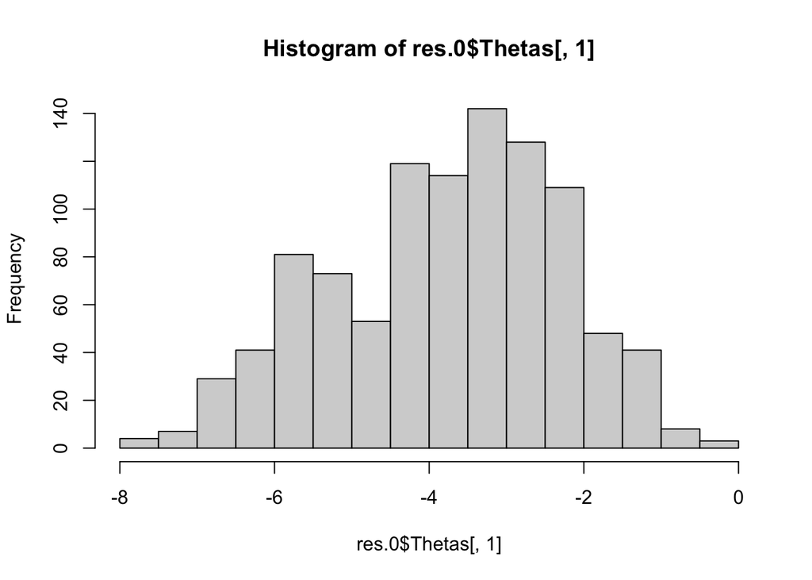

```r
hist(res.0$Thetas[,1])
```

And bivariate plots can also be made manually

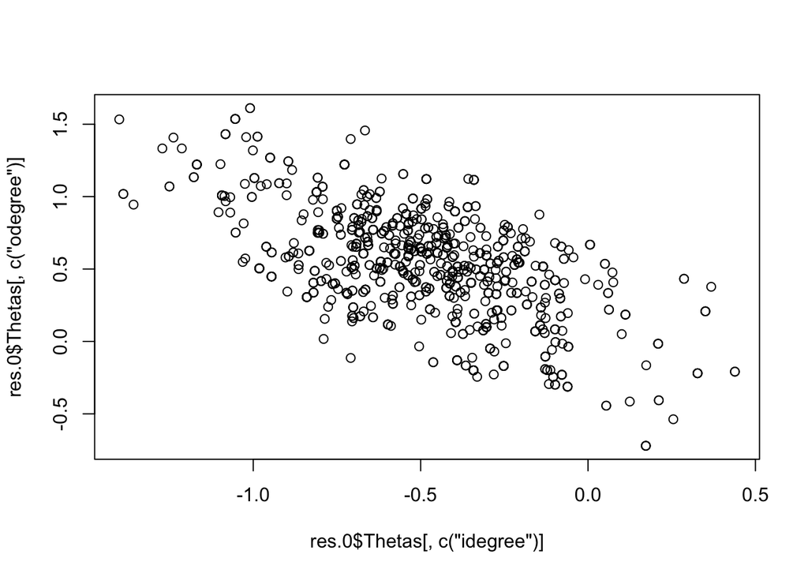

```r
plot(res.0$Thetas[,c('idegree')],res.0$Thetas[,c('odegree')])
```

### Graphing posteriors

In `balaam` the function `plotPost`, produces histograms, trace plots, and autocorrelation plots for all parameters in your model.

```
## Parameter  2  all zeros
```

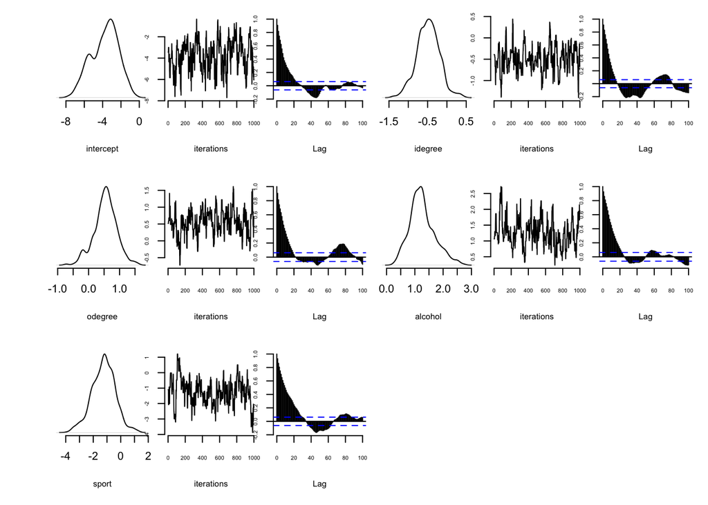

```r
plotPost(res.0,figname='markov 0',showplot=TRUE)
```

> We see that the posterior distribution for `alcohol` is concentrated to the right of 0.

# MCMC performance

## Explaining MCMC

The MCMC algortihm generates a sequence

$$\boldsymbol{\theta}_0,\boldsymbol{\theta}_1,\ldots,\boldsymbol{\theta}_T$$

of $T$ paramter draws from the posterior $\pi(\boldsymbol{\theta} \mid \mathbf{y})$. The draws are made by proposing a new value $\boldsymbol{\theta}^{\ast}$ given a current value $\boldsymbol{\theta}_t$ in iteration $t$
$$\boldsymbol{\theta}^{\ast} \mid \boldsymbol{\theta}_t \thicksim
\mathcal{N}_p( \boldsymbol{\theta}_t , \boldsymbol{\Sigma}).$$

This new value is either accepted, and $\boldsymbol{\theta}_{t+1}$ is set to $\boldsymbol{\theta}^{\ast}$, or rejected, in which case $\boldsymbol{\theta}_{t+1}$ is set to $\boldsymbol{\theta}_{t}$.

### Trace plots

We can plot the sequence of updates $\boldsymbol{\theta}_0,\ldots,\boldsymbol{\theta}_T$, to get a sense of whether updates are large or small, and if many or few proposed values $\boldsymbol{\theta}^{\ast}$ are accepted

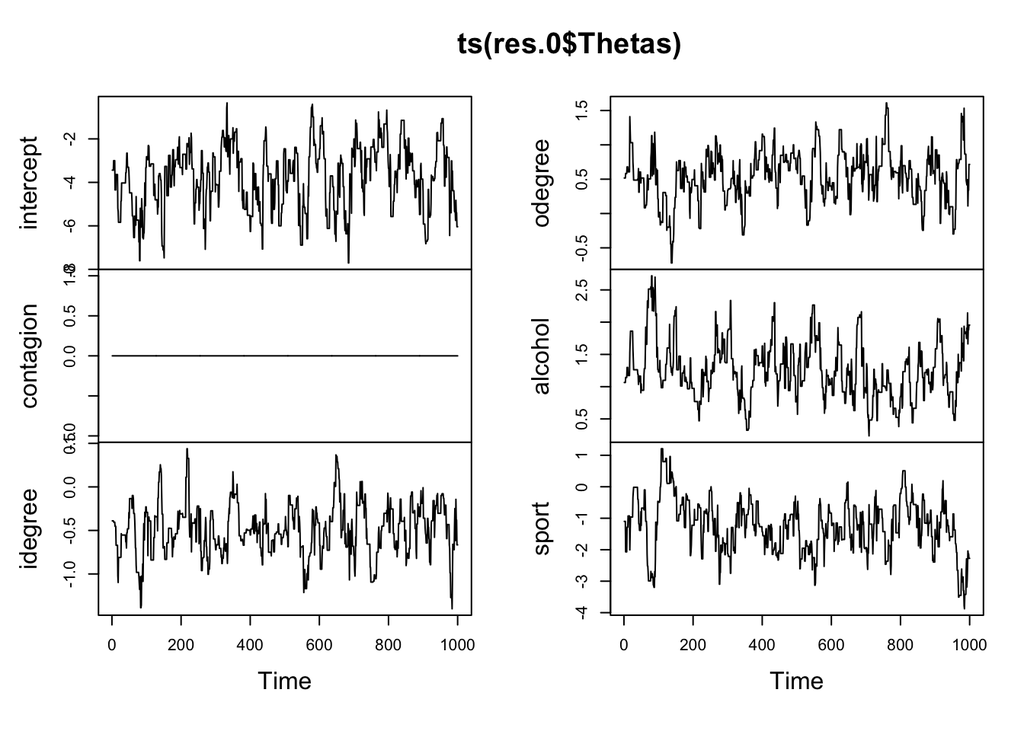

```r
plot( ts( res.0$Thetas) )
```

What we are looking for in the trace plots are

1. Is there too much dependence on the initial value $\boldsymbol{\theta}_0$ - is there a trend?
2. Are the changes too small?
3. Are too many/few updates accepted

## Diagnosing MCMC

### Initial values

The default is to set $\boldsymbol{\theta}_0$ to the maximum likelihood estimate (MLE) for an independent model. These starting values should be sufficiently good for most models. We can however look at the contagion parameter for the DC model, for which the parameter is intialised in $\theta_{DC}=0$

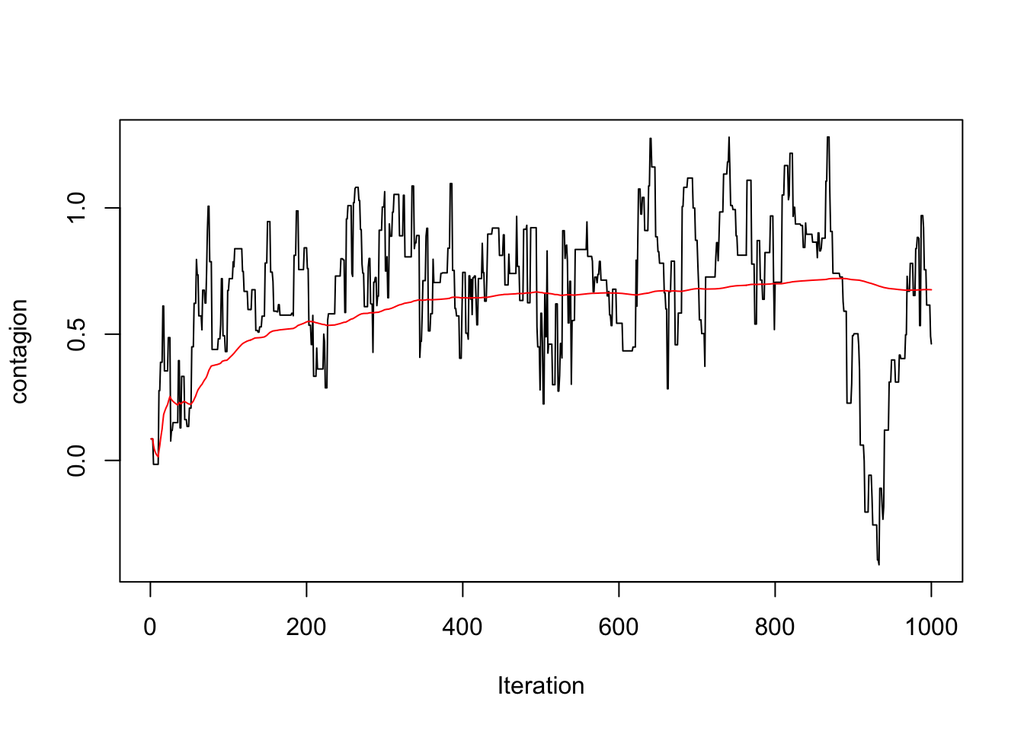

```r
plot( ts( res.DC.0$Thetas[,2]), ylab=colnames(res.DC.0$Thetas)[2], xlab='Iteration' )
lines( cumsum(res.DC.0$Thetas[,2])/c(1:1000), col='red')
```

> There is somehing of an increasing trend

### Autocorrelation

Since the MCMC is iterative, the chains could

- could stay in one place for a number of iterations, or
- make very small updates, if $\boldsymbol{\theta}^{\ast}$ are close to $\boldsymbol{\theta}_t$

This would mean that values $\boldsymbol{\theta}_{t}$ and $\boldsymbol{\theta}_{s}$, for iterations $s$ and $t$ that are close to each other, are likely to be more similar, more correlated, than for iterations $s$ and $t$ that are far appart. This is the first sources of *serial autocorrelation* in the chains. The second source, relates to how big jumps we propose, i.e. how close is $\boldsymbol{\theta}^{\ast}$ to the current value $\boldsymbol{\theta}_t$ in iteration $t$? If we make too small jumps, values or iterations $s$ and $t$ that are close to each other will be highly correlated.

A perfect sampler would propose and accept $\boldsymbol{\theta}^{\ast}$ regadeless of where we currently are in iteration $t$. If this were the case, then the effective sammple size would be equal to the total number of iterations. As a ficticious example, consider drawing 100 normal variates

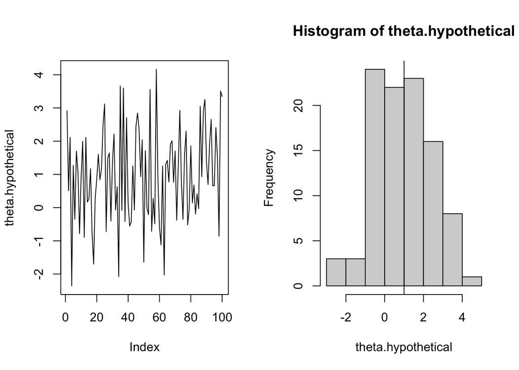

```r
# WHITE NOISE
theta.hypothetical <- rnorm(100, mean =1, sd=1.5)
par( mfrow= c(1,2) )
plot(theta.hypothetical,type='l')
hist(theta.hypothetical)
abline(v=1)
```

For ALAAM posteriors we have three ways of checking the autocorrelation.

#### SACF

The results table provide the sample autocorrelation between draws $\boldsymbol{\theta}_{t}$ and $\boldsymbol{\theta}_{t+k}$, for lags $k=10$ and $k=30$.

```r
res.DC.0$ResTab
```

```
##                 mean         sd        ESS    SACF 10    SACF 30
## intercept -3.2629761  1.4288453 30.0255225  0.5687323  0.0918630
## contagion  0.6759112  0.2834600 28.5686122  0.5856936  0.2394995
## idegree   -0.8811403  0.3712178 20.0896910  0.6987023  0.3603367
## odegree    0.3413330  0.3516642 30.4911367  0.5566014  0.1523902
## alcohol    1.0899707  0.4247780 26.3143825  0.5844120  0.1172474
## sport     -1.0815416  0.7876541 29.4332690  0.5704428  0.1866902
```

#### plotPost

The plotting function gives us the correlations for all lags.

#### ACF plot

We can use the standard function `acf`, for example for the contagion parameter

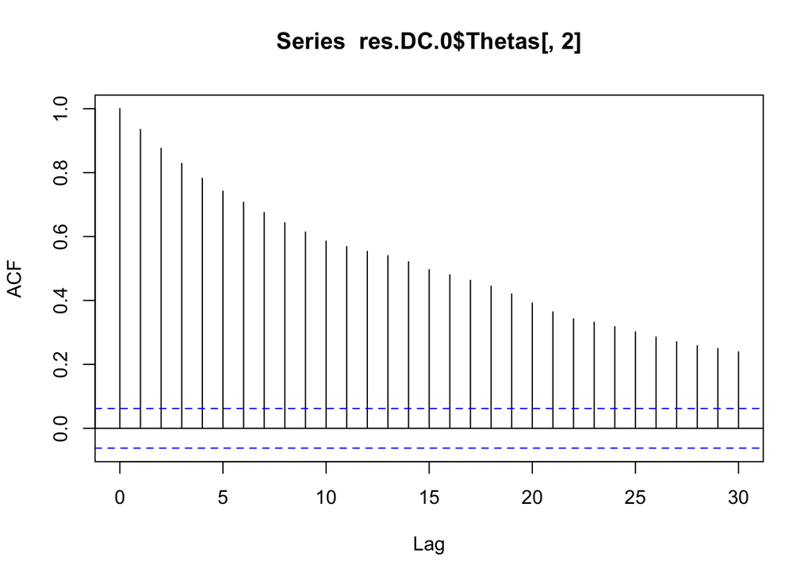

```r
acf( res.DC.0$Thetas[,2] )
```

We can compare this with the white noise, where we have 100 *independent draws*.

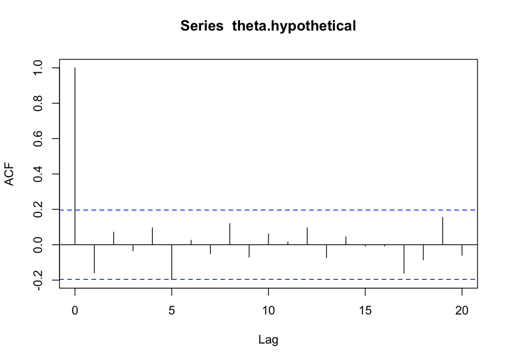

```r
acf(theta.hypothetical)
```

```r
as.numeric(acf(theta.hypothetical,plot=FALSE)[c(5,10)][[1]])
```

```
## [1] -0.1976251  0.0611485
```

> With high autocorrelation we need more iterations to get a “representative” sample from the posterior

Intuitively, with high autocorrelation

> Your posterior will look very different depending on what subset of iterations you look at!

**NOTE** The log-run behaviout of the Monte carlo mean
$$\bar{\boldsymbol{\theta}}=\frac{1}{T}\sum_{t=0}^T\boldsymbol{\theta}_t$$

will not be affected by high autocorrelation. The long-run behaviour (and quality) of the Monte Carlo estimate of the variance-covariance matrix
$$\bar{V}(\boldsymbol{\theta})=\frac{1}{T}\sum_{t=0}^T\boldsymbol{\theta}_t\boldsymbol{\theta}_t^{\top}-\bar{\boldsymbol{\theta}}\bar{\boldsymbol{\theta}}^{
\top}$$

and posterior credibility intervals will be (potentially) severely affected.

#### ESS

```r
effectiveSize(theta.hypothetical)
```

```
##     var1
## 136.4792
```

For the DC model, we did 1000 iteration and the reported ESS was around 30 for most parameters. This means that we need to do roughly

```r
1000/30
```

```
## [1] 33.33333
```

updates in the MCMC for every approximately independent draw.

# Improving MCMC

1. To reduce dependence on the initial value, we can start in a better $\boldsymbol{\theta}_0$
2. To reduce SACF, we can “space out” our sample by only using every $k$th iteration - `thinning`
3. To reduce SACF, we can optimise how large updates $\boldsymbol{\theta}^{\ast}$ we do to $\boldsymbol{\theta}_t$, by calibrating $\boldsymbol{\Sigma}$ in the proposal distribution.

## Using prevBayes

```r
# Previous call for reference
#res.DC.0 <- estimate.alaam(smoke ~idegree+odegree+alcohol+sport+simple, my.data, adjacency=adj,
#                           Iterations=1000)
res.DC.1 <- estimate.alaam(smoke ~idegree+odegree+alcohol+sport+simple, my.data, adjacency=adj,
                           Iterations=5100,
                        prevBayes=res.DC.0,# our first estimation
                        par.burnin=100,# discard the first 100 iterations
                        thinning=10)# only use every
```

```
## [1] "you have p:  6"
##
## observed stats:  17 25 40 43 59 11
## number of covariates:  4
## A thinning of  10 ,
## (parameter) burn-in of  100 , and
## iterations of  5100 ,
## yields a sample size of  501 .
##
## you have done  510  iterations out of  5100
## theta: -4.117 0.616 -1.036 0.629 1.467 -1.801
## you have done  1020  iterations out of  5100
## theta: -2.062 1.058 -0.863 0.253 0.448 -0.881
## you have done  1530  iterations out of  5100
## theta: -4.672 0.135 0.019 0.398 1.048 -0.752
## you have done  2040  iterations out of  5100
## theta: -2.815 0.683 -0.649 0.659 0.411 -0.338
## you have done  2550  iterations out of  5100
## theta: -3.756 0.545 -0.223 -0.206 0.861 0.076
## you have done  3060  iterations out of  5100
## theta: -0.855 0.982 -0.982 -0.013 0.642 -1.665
## you have done  3570  iterations out of  5100
## theta: -3.874 0.661 -1.46 0.89 1.148 -0.324
## you have done  4080  iterations out of  5100
## theta: -3.507 0.663 -1.364 0.872 1.067 -0.596
## you have done  4590  iterations out of  5100
## theta: -5.17 0.686 -0.295 0.45 0.663 0.115
## you have done  5100  iterations out of  5100
## theta: -4.065 0.441 -1.089 0.916 1.381 -2.038
## summaries of the posterior draws:
##               mean       sd      ESS  SACF 10 SACF 30
## intercept  -3.4233   1.5534  96.5529  -0.0623
## contagion   0.6512   0.2900 102.7933   0.0331
## idegree    -0.8721   0.4135  43.1749   0.1437
## odegree     0.4904   0.3869  70.8873   0.1231
## alcohol     1.0111   0.4108  85.7303   0.0473
## sport      -1.0424   0.7787  91.3480   0.0524
##
## if ESS is small you need to increase the number of Iterations
## if and/or increase the parameter thinning which is currently  10 .
## Alternatively, adjust the proposals by improving the proposal variance-covariance:
## e.g. set PropSigma equal to the covariance of the posterior draws, or
## increase/decrease the scaling of the proposals (default: scaling=1/sqrt( 6 ); current:  1 /sqrt( 6 )
## Acceptance ratio:  0.4913725  (idealy around 0.25)
```

> Draws 10 iterations apart are now very close to independent, judging by the SACF. ESS are close to 100.

The figures look promising but the proportion of accepted proposals (acceptance ratio) is high. This suggests that chains might be making too small moves. Check trace plots

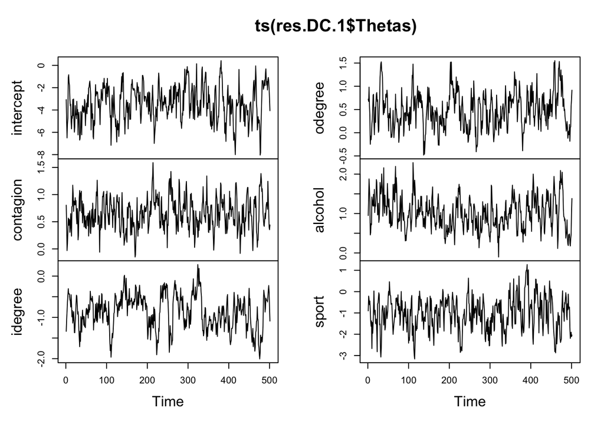

```r
plot( ts( res.DC.1$Thetas ))
```

## Calibrate proposal

If we set `recalibrate` equal to TRUE, we will estimate $\hat{\boldsymbol{\Sigma}}=V(\boldsymbol{\theta} \mid \boldsymbol{y})$, and propose moves from
$$\boldsymbol{\theta}^{\ast} \mid \boldsymbol{\theta}_t \thicksim
\mathcal{N}_p( \boldsymbol{\theta}_t ,
\tfrac{c}{\sqrt{p}}\hat{\boldsymbol{\Sigma}})$$
The tuning constant $c$ is given by the argument `scaling`.

```r
res.DC.2 <- estimate.alaam(smoke ~idegree+odegree+alcohol+sport+simple, my.data, adjacency=adj,
                           Iterations=5100,
                           prevBayes=res.DC.0,# our first estimation
                           par.burnin=100,# discard the first 100 iterations
                           thinning=10,# only use every 10
                           recalibrate=TRUE,# use proposal variance from previous posterior
                           scaling = 0.75)# scale down
```

```
## [1] "you have p:  6"
##
## observed stats:  17 25 40 43 59 11
## number of covariates:  4
## A thinning of  10 ,
## (parameter) burn-in of  100 , and
## iterations of  5100 ,
## yields a sample size of  501 .
##
## you have done  510  iterations out of  5100
## theta: -2.869 0.744 -0.547 0.461 0.643 -1.782
## you have done  1020  iterations out of  5100
## theta: -3.516 0.739 -1.834 0.856 1.703 -1.664
## you have done  1530  iterations out of  5100
## theta: -5.232 1.082 -1.309 0.803 1.271 -0.042
## you have done  2040  iterations out of  5100
## theta: -4.196 0.293 -0.708 0.681 1.148 -1.233
## you have done  2550  iterations out of  5100
## theta: -2.876 -0.15 -0.807 0.949 1.255 -3.209
## you have done  3060  iterations out of  5100
## theta: -1.794 0.334 -0.338 0.198 0.563 -0.742
## you have done  3570  iterations out of  5100
## theta: -6.141 1.354 -0.999 0.192 1.55 -0.629
## you have done  4080  iterations out of  5100
## theta: -3.375 0.76 -0.597 0.244 0.961 -1.921
## you have done  4590  iterations out of  5100
## theta: -3.603 0.422 -0.716 0.313 1.387 -1.679
## you have done  5100  iterations out of  5100
## theta: -3.341 0.293 -0.546 0.644 0.922 -1.397
## summaries of the posterior draws:
##              mean      sd     ESS SACF 10 SACF 30
## intercept -3.6968  1.7982 30.4028  0.2763
## contagion  0.6567  0.3710 38.5100  0.0860
## idegree   -0.8236  0.4297 33.6715  0.2080
## odegree    0.4871  0.4587 32.2639  0.2828
## alcohol    1.0642  0.4512 50.9032  0.1358
## sport     -1.1922  0.8784 48.6435  0.1228
##
## if ESS is small you need to increase the number of Iterations
## if and/or increase the parameter thinning which is currently  10 .
## Alternatively, adjust the proposals by improving the proposal variance-covariance:
## e.g. set PropSigma equal to the covariance of the posterior draws, or
## increase/decrease the scaling of the proposals (default: scaling=1/sqrt( 6 ); current:  0.75 /sqrt( 6 )
## Acceptance ratio:  0.04098039  (idealy around 0.25)
```

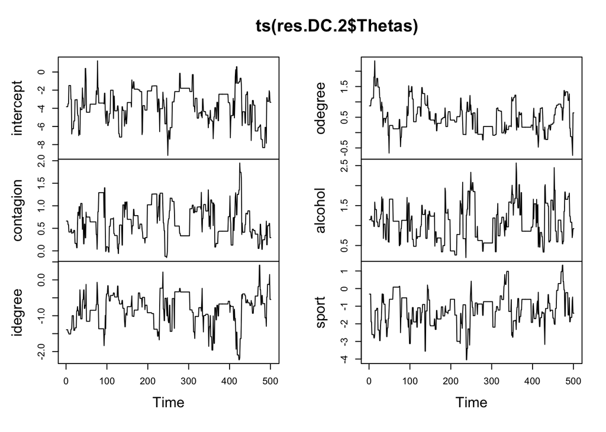

```r
plot( ts( res.DC.2$Thetas ))
```

> Chains seem to make big moves but very few proposals are accepted.

Possible remedies include 1. Reduce scaling 2. Buy mixing by increasing iterations and thinning 3. Recalibrate yet another time

# What is a good ESS

That the chains are not trending and that autocorrelation is not too high more imporant that a single number. Conceptually, if you have an ESS of, say, 10, then you will only have precision down to the first decimal. With ESS of 1000, you can have precision down to maybe the second or third decimal.

# More on the algoritm

When determining whether to accept $\boldsymbol{\theta}^{\ast}$, a replicate dataset $\boldsymbol{y}^{\ast}$, is drawn from the model
$$\boldsymbol{y}^{\ast} \thicksim
p_{\boldsymbol{\theta}^{\ast}}(\boldsymbol{y} | \mathbf{X} )$$
The parameter $\boldsymbol{\theta}^{\ast}$ is accepted into the posterior is $\boldsymbol{y}^{\ast}$ sufficiently similar to observed data $\boldsymbol{y}$. More specifically, the parameter is accepted with probability
$$\min \left\{1,e^h \right\}$$
where
$$h =
(\boldsymbol{\theta}_t-\boldsymbol{\theta}^{\ast})^{\top}(\boldsymbol{z}(\boldsymbol{y}^{\ast},\mathbf{X})-\boldsymbol{z}(\boldsymbol{y},\mathbf{X}))$$

We cannot draw $\boldsymbol{y}^{\ast}$ directly from the model, but will have to rely on MCMC. This algorithm is similar to how we generate $\boldsymbol{\theta}$ iteratively, a sequence
$$\boldsymbol{y}^{\ast}_0,\boldsymbol{y}^{\ast}_1,\ldots,\boldsymbol{y}^{\ast}_M$$
is generated and only the last iteration is used. The number $M$ of iterations we use in order to get one draw, is set by the argument `burnin`. This number should be at least
$$M > 0.25 \times n \times \kappa$$

for $\kappa$ greater than 30.

# GOF

To appraise how well the estimate model replicates data, the goodness-of-fit (GOF) procedure simulates replicate data
$$\boldsymbol{y}_t^{(rep)}\thicksim
p_{\boldsymbol{\theta}_t}(\boldsymbol{y}^{(rep)} | \mathbf{X} )$$
for the each of the parameter dras $\boldsymbol{\theta}_t$ in our posterior sample. Fit of the replicate data to observed data is then judged by comparing $\boldsymbol{y}_t^{(rep)}$ to $\boldsymbol{y}$ on a number of metrics $S_k:\mathcal{Y}\times\mathcal{X} \rightarrow \mathbb{R}$. The posterior $p$-value is defined as
$$\mathbb{E}[|S_k(\boldsymbol{y}^{(rep)})-\mathbb{E}(S_k(\boldsymbol{y}^{(rep)}))|>|S_k(\boldsymbol{y})-\mathbb{E}(S_k(\boldsymbol{y}^{(rep)}))|]$$
### GOF Statistics

The pre-programmed statistics $S_k$ are

| GOF-name | interpretation | statistic |
| --- | --- | --- |
| intercept | intercept | $\sum y_{i}$ |
| simple cont. | direct contagion through outgoing ties | $\sum y_{i}y_{j}x_{i,j}$ |
| recip cont. | contagion through reciprochated ties | $\sum y_{i}y_{j}x_{i,j}x_{j,i}$ |
| indirect cont. | indirect contagion | $\sum_{j,k}y_ix_{i,j}x_{j,k}y_k$ |
| closedind cont. | contaigion in closed triad | $\sum_{j,k}y_ix_{i,j}x_{j,k}x_{i,k}y_k$ |
| transitive cont. | contagion in transitive triple | $\sum_{j,k}x_{i,j}x_{j,k}x_{i,k}y_iy_jy_k$ |
| outdegree | Markov outdegree | $\sum y_{i}\sum_j x_{i,j}$ |
| indegree | Markov outdegree | $\sum y_{i}\sum_j x_{j,i}$ |
| reciprochation | Markov reciprochal ties | $\sum y_{i}\sum_j x_{i,j}x_{i,j}$ |
| instar | Markov in-star | $\sum y_{i} {\binom{\sum_j x_{i,j}}{2}}$ |
| outstar | Markov out-star | $\sum y_{i} {\binom{\sum_j x_{j,i}}{2}}$ |
| twopath | Markov mixed star | $\sum y_{i} \sum x_{i,j}x_{i,k}$ |
| in3star | Markov in-three star | $\sum y_{i} \sum x_{j,i}x_{k,i}x_{h,i}$ |
| out3star | Markov out-three star | $\sum y_{i} \sum x_{i,j}x_{i,k}x_{i,h}$ |
| transitive | Markov transitive triangle | $\sum y_i \sum_{j,k}x_{i,j}x_{j,k}x_{i,k}$ |
| cyclic | Markov cyclic triangle | $\sum y_i \sum_{j,k}x_{i,j}x_{j,k}x_{k,i}$ |
| indirect | Markov indirect, non-exclusive ties | $\sum_{j} (x_{i,j} x_{j, +} - x_{i,j}x_{j,i})$ |
| excl.indirect | Markov indirect, unique nodes | $\sharp \{ k : x_{ik}=0,\max_j(x_{i,j}x_{j,k})>0 \}$ |
| prop.alc.alter | a user-defined alter attribute variable | $\frac{1}{1+x_{i,+}} \sum x_{i,j}a_{j}$ |

## Generate GOF distribution

To generate a sample from the model implied by the independent model

```r
sim.0 <- get.gof.distribution(NumIterations=100, # number of vectors to draw
                                  res=res.0, # the ALAAM estimation object that contains model and results
                                  burnin=100, # no. iteractions discarded from GOF distribution
                                  contagion ='none') # should be the same as for model fitted
```

```
## Simulating GOF took  1.040042
## Calculating statistics took  0.1132641
```

# Calculate the statistics

```r
gof.table(obs.stats=    sim.0$stats, # observed statistics included  not fitted statistics
          sim.stats=    sim.0$Sav.gof, # simulated goodness-of-fit statistics
          name.vec= sim.0$gof.stats.names, # names of statistics calculate, not all will be used if undirected
          tabname='ALAAMGofalt', # name of file saved
          pvalues=TRUE, # posterior predictive p-values
          save.tab ='csv', # save a csv file or a LaTex file
          directed=FALSE)
```

```
##                     obs   mean  p-val
## intercept        17.000 16.840  0.205
## simple cont.     25.000 18.720  0.110
## recip cont.       7.000  6.340  0.170
## indirect cont.   59.000 32.180  0.030
## closedind cont.  22.000 16.200  0.100
## transitive cont. 13.000  9.320  0.150
## degree           43.000 41.520  0.220
## reciprochation   26.000 27.150  0.200
## instar           57.000 46.400  0.140
## outstar          44.000 41.060  0.210
## twopath          88.000 80.870  0.200
## in3star          71.000 41.230  0.135
## out3star         22.000 21.000  0.215
## triadic          34.000 35.120  0.205
## cyclic           18.000 21.990  0.125
## indirect         93.000 82.350  0.170
## excl.indirect    53.000 42.990  0.130
```

> The independent model struggles to replicate the contagion effects

Repeat for the simple contagion model

```r
sim.2 <- get.gof.distribution(NumIterations=100, # number of vectors to draw
                                  res=res.DC.2, # the ALAAM estimation object that contains model and results
                              thinning= 2000,# number of iterations to draw y
                                  burnin=100, # no. iteractions discarded from GOF distribution
                                  contagion ='simple') # should be the same as for model fitted
```

```
## Simulating GOF took  1.996031
## Calculating statistics took  0.04133916
```

```r
gof.table(obs.stats=    sim.2$stats, # observed statistics included  not fitted statistics
          sim.stats=    sim.2$Sav.gof, # simulated goodness-of-fit statistics
          name.vec= sim.2$gof.stats.names, # names of statistics calculate, not all will be used if undirected
          tabname='ALAAMGofalt', # name of file saved
          pvalues=TRUE, # posterior predictive p-values
          save.tab ='csv', # save a csv file or a LaTex file
          directed=FALSE)
```

```
##                     obs   mean  p-val
## intercept        17.000 17.410  0.215
## simple cont.     25.000 24.760  0.220
## recip cont.       7.000  8.620  0.175
## indirect cont.   59.000 41.490  0.095
## closedind cont.  22.000 20.380  0.195
## transitive cont. 13.000 15.400  0.220
## degree           43.000 43.440  0.250
## reciprochation   26.000 27.340  0.220
## instar           57.000 42.610  0.130
## outstar          44.000 44.540  0.225
## twopath          88.000 80.710  0.200
## in3star          71.000 35.150  0.115
## out3star         22.000 24.870  0.175
## triadic          34.000 37.330  0.170
## cyclic           18.000 21.630  0.160
## indirect         93.000 89.780  0.230
## excl.indirect    53.000 48.040  0.170
```

> No indications of poor fit

# Model selection

GOF only checks if there are features of data that are not adequately captured by the model. We cannot say **how much** better or worse the GOF for one model is compared to another - either the model fits or it does not (and we do not want to overfit).

To compare models we may quantify the fit of a model, drawing by analogy with standard generalised linear models.

## Posterior deviance

Aitkin, Vu, and Francis (2017) proposed that a graphical comparison of models can be done through comparing the posterior distribution of the deviance. The deviance is here defined as minus twice the log likelihood
$$D(\boldsymbol{\theta})=-2 \log[p_{\boldsymbol{\theta}}(\boldsymbol{y} |
\mathbf{X} )].$$
Calculate the deviance $D(\boldsymbol{\theta}_t)$ for the parameters in your posterior.

> Models with smaller deviance are prefered to models with large deviance

### Independent model

The deviances can be calculated exactly for the independent model

```r
ind.post.dev <- post.deviance.alaam(res.0)
```

### Contagion model

For the model with contagion, numerical methods are required (see `alaam_effects.pdf`). The arguments are here deliberately set too low to speed up the calculateions.

When evaluating deviance across the posterior draws, we ideally want to have suffiently spaced out and approximately independent draws from the posterior os possible. In the list of arguments `burnin` is the number of parameter draws that are discarded and `thinning` is the number of iterations that are discarded between sample draws. Node that if `dim(res.1$Thetas)[1]` is $N$, then the total number of parameter draws you use will be `(N-burnin)/thinning`.

Calculating the posterior deviances is done based on path of length `numbridges`, linking `thetaRef` with the paramter. The (log) ration of normalising constants is estimated based on a MCMC sample from the model based on `numYsamps`. This sample size has to be large but does not have to be too large. The thining in generating these vectors is `Yburnin`. The larger this and numYsamps` the better precision you get.

> Evaluating the deviance takes a while - be patient; the routine will print to screen how many paramters you have eveluated the relative deviance for out of the total number

```r
my.dev.post <- post.deviance.alaam(res.DC.2,# the estimation object
                                  numBridges=5,# the safer default is 20
                                  thinning.like = 1000,# thinning in drawing y; should be higher
                                  sample.size = 20,# number of y drawn for each bridge
                                  cov.sample.burnin = NULL,
                                  printFreq=10,# print to screen after done 10
                                  mult.fact = 30,# depreciated
                                  num.outs=100)# number of devaiance evaluations to return
```

```
##
## Likelihood evaluated for draw  10  (out of  100 )
## Likelihood evaluated for draw  20  (out of  100 )
## Likelihood evaluated for draw  30  (out of  100 )
## Likelihood evaluated for draw  40  (out of  100 )
## Likelihood evaluated for draw  50  (out of  100 )
## Likelihood evaluated for draw  60  (out of  100 )
## Likelihood evaluated for draw  70  (out of  100 )
## Likelihood evaluated for draw  80  (out of  100 )
## Likelihood evaluated for draw  90  (out of  100 )
## Likelihood evaluated for draw  100  (out of  100 )
```

### Visualising deviance

Aitkin, Vu, and Francis (2017) recomnded comparing the distributions in terms of their cumulative distribution functions
$$\Pr(D(\boldsymbol{\theta})<d )$$

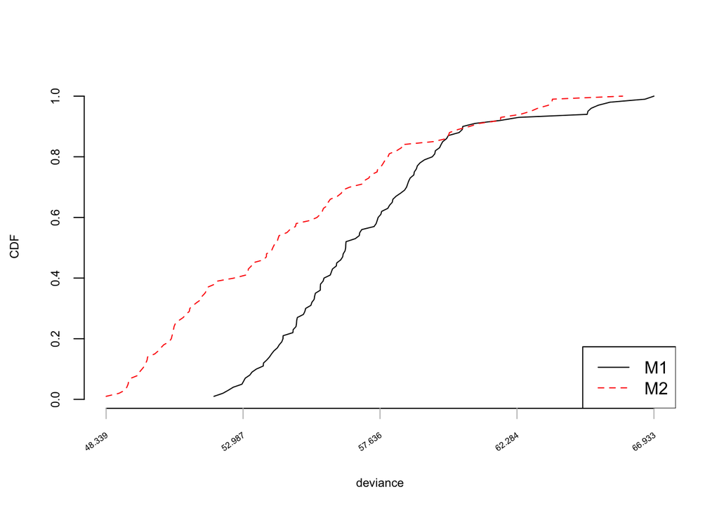

```r
plot.deviance.alaam(dev.1=ind.post.dev, dev.2=my.dev.post)
```

> There is separatation between the CDFs

## DIC

The DIC can be calcualted from the posterior deviances using the formula of Spiegelhalter et al. (2002) or Gelman et al. (2013). The difference between the two ways of calculating DIC lies in the calculation of $p_D$. Here we use
$$DIC= E[D(\boldsymbol{\theta})]+V(D(\boldsymbol{\theta}))/2$$
Calculate the DIC for the two models using `alaam.dic`

```r
c( alaam.dic(ind.post.dev),alaam.dic(my.dev.post) )
```

```
## [1] 62.45737 63.58895
```

> What model is the winner? Smaller is better

# References

Aitkin, Murray, Duy Vu, and Brian Joseph Francis. 2017. “Statistical Modelling of a Terrorist Network.” *Journal of the Royal Statistical Society: Series A Statistics in Society* 180 (3): 751–68.

Butts, Carter T. 2015. *_Network: Classes for Relational Data_. The Statnet Project*. https://CRAN.R-project.org/package=network.

———. 2016. *_Sna: Tools for Social Network Analysis*. https://CRAN.R-project.org/package=sna.

Daraganova, Galina. 2009. *Statistical Models for Social Networks and Network-Mediated Social Influence Processes: Theory and Applications*. University of Melbourne.

Daraganova, Galina, and Garry Robins. 2013. “Autologistic Actor Attribute Models.” In *Exponential Random Graph Models for Social Networks: Theory, Methods and Applications*, edited by Lusher D., Koskinen J., and G. Robins, 102–14. NY: Cambridge University Press New York.

Gelman, Andrew, John B Carlin, Hal S Stern, David B Dunson, Aki Vehtari, and Donald B Rubin. 2013. *Bayesian Data Analysis*. CRC press.

Koskinen, Johan, and Galina Daraganova. 2022. “Bayesian Analysis of Social Influence.” *Journal of Royal Statistical Society, Series A* 185 (4): 1855–81.

Robins, Garry, Philippa Pattison, and Peter Elliott. 2001. “Network Models for Social Influence Processes.” *Psychometrika* 66 (2): 161–89.

Spiegelhalter, David J, Nicola G Best, Bradley P Carlin, and Angelika Van Der Linde. 2002. “Bayesian Measures of Model Complexity and Fit.” *Journal of the Royal Statistical Society: Series b (Statistical Methodology)* 64 (4): 583–639.